Econometrics and Statistics (520K)

# Econometric Methods in Business and Economics

Practical Class (Winter 24/25)

by Domenic Franjic

# Exercise Sheet No 11

Regression Analysis of Time Series Data (Part 1)

## Set-Up

1) Create your (working) directory

Create a new folder on your computer in which you can save all necessary files, i.e., the data set, the R *script* with the implementation of your analysis and the R *helper function script* with some helper functions provided by us.

This folder, i.e., the path or directory of this folder, will be your so-called working directory.

2) Download the data set

Download the data set `us_macro_data` from ILIAS directly or by using the link below:

[Download `us_macro_data`](https://ilias.uni-hohenheim.de/goto.php?target=file_1558777_download&client_id=UHOH)

Save the data set into a (working) directory of your choice.

3) Prepare *script*

Open a new R *script* and save it into into your (working) directory.

Run the following code chunk to prepare your R *script*, i.e., to clear the work space and set your working directory.

```r
# Clear workspace
rm(list = ls(all = TRUE))
# Set working directory
setwd(".../set/your/working/directory/...")
```

4) Install/load *packages* and download/save/include *helper function script*

Step 1) Install all relevant R *packages* and download and save the R *script* `r_helper_functions.R` from ILIAS by running the following code chunk.

```r
# Download R-helper functions
source("https://ilias.uni-hohenheim.de/data/UHOH/lm_data/lm_1856939/MA_EconometricMethods_WiSe2324_PracticalClass/r-scripts/prepare_r_packages_and_helper_functions.R")
```

*Note*, the required R *packages* are `"moments"`, `"sandwich"`, `"lmtest"`, `"lmtest"`, `"car"`, `"plm"`, `"ivreg"`, `"dynlm"`, `"forecast"`, `"urca"`.

Step 2) Include the R *script* `r_helper_functions.R` into your R *script* by running the following code chunk.

```r
# Include R-helper functions
source("r_helper_functions.R")
```

*Note*, more information on the helper functions can be found here.

## Task

US Real Gross Domestic Product (GDP)

We return to the analysis of US Real Gross Domestic Product (GDP). For this we use the data set `us_macro_data.txt` containing quarterly US macro data from 1955:Q2 - 2017:Q4 with the variables described in Table 1 on the exercise sheet and depicted in Figure 1 on the exercise sheet.

| Variable | Description |
| --- | --- |
| $GDP$ | Real GDP in Billions of $2009 |
| $GDPGR$ | Annualized real GDP growth |
| $TSpread$ | Spread between 10Y and 3M treasury yields |

```
##
## =============================================================
##             Model 1          Model 2          Model 3
## -------------------------------------------------------------
## constant      1.950 (0.322)    1.603 (0.369)    0.945 (0.462)
## GDPGR_L1      0.341 (0.073)    0.279 (0.076)    0.246 (0.076)
## GDPGR_L2                       0.177 (0.077)    0.176 (0.076)
## TSpread_L1                                     -0.134 (0.420)
## TSpread_L2                                      0.623 (0.428)
## -------------------------------------------------------------
## AIC           2.242            2.219            2.196
## BIC           2.273            2.265            2.272
## Num. obs.   223              223              223
## =============================================================
```

```
##         GDPGR TSpread
## 2016 Q3  2.74    1.26
## 2016 Q4  1.74    1.70
## 2017 Q1  1.23    1.85
## 2017 Q2  3.01    1.37
## 2017 Q3  3.11    1.20
## 2017 Q4  2.50    1.16
```

### Task a)

Briefly describe the time series plot of GDP in levels and the growth rate of GDP depicted in Figure 1 on the exercise sheet.

Load data set

```r
# use absolute or relative path to load data
macro.dat <- read.table("us_macro_data.txt",
                        header = TRUE,
                        sep = ",",
                        colClasses = c("character","numeric","numeric","numeric"))
```

Transform variables into `ts` class

```r
# Transform all macro variables
macro.ts <- ts(macro.dat[,-1], frequency = 4, start = c(1955, 2), end = c(2017, 4)) # I omit the date
# Transform GDP level series
gdp.ts <- ts(macro.dat$GDP, frequency = 4, start = c(1955, 2), end = c(2017, 4))
# Transform GDP growth series
gdp.grw.ts <- ts(macro.dat$GDPGR, frequency = 4, start = c(1955, 2), end = c(2017, 4))
```

Create date variable with class `Date`

```r
# Transform variable
TT <- length(macro.dat$DATE)
tax <- seq(as.Date("1955/4/1"), by = "quarter", length.out = TT)
```

Plot

```r
# Time series plot of GDP
plot(x = tax, y = macro.dat$GDP, type = "l",
     main = "US real GDP",
     xlab = "Quarter",
     ylab = "Level")
```

```r
# Time series plot of GDPGR
plot(x = tax, y = macro.dat$GDPGR, type = "l",
     main = "US real GDP growth",
     xlab = "Quarter",
     ylab = "Annual growth rate")
lines(x = tax, y = rep(0,TT), type = "l", lty = 2)
```

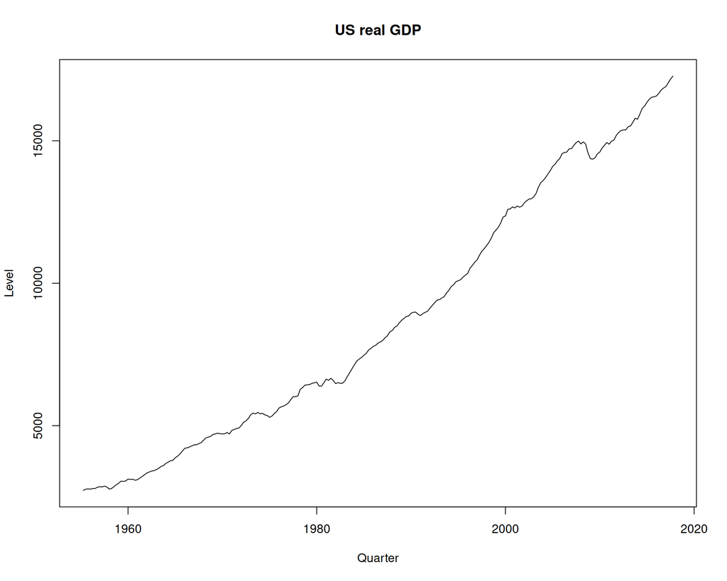

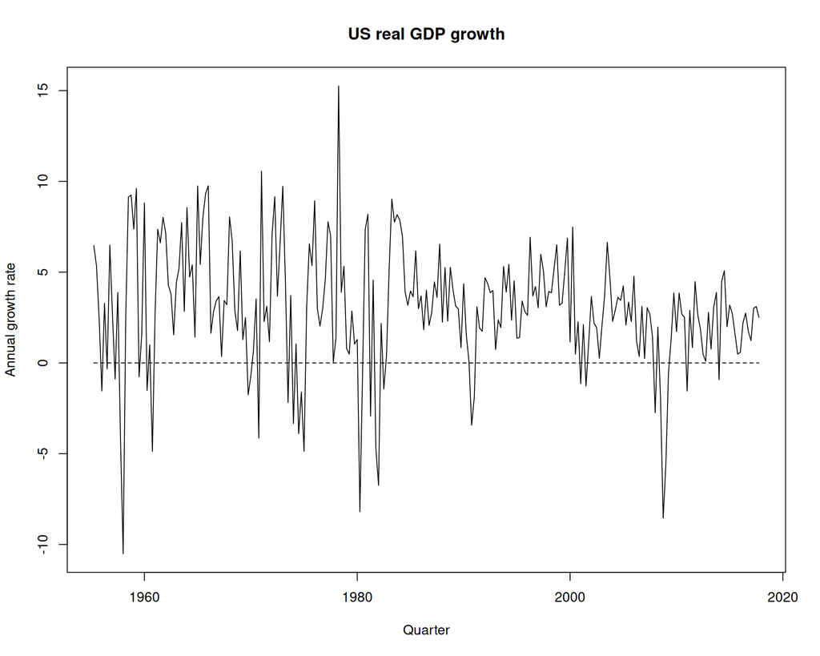

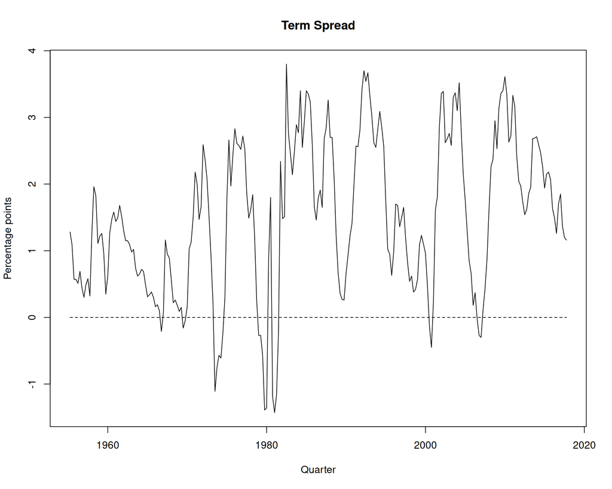

```r
# Time series plot of TSpread
plot(x = tax, y = macro.dat$TSpread, type = "l",
     main = "Term Spread",
     xlab = "Quarter",
     ylab = "Percentage points")
lines(x = tax, y = rep(0,TT), type = "l", lty = 2)
```

Discussion

GDP (level)

- There seems to be a upward trend.
- Standard statistics such as mean and variance are not meaningful!

GDP (growth rate) and TSpread

- There seems to be no upward trend.
- Standard statistics such as mean and variance are meaningful.

*Add your Interpretation here!*

### Task b)

Explain the concept of sample autocorrelations. Interpret the estimation results for the sample autocorrelations for the growth rate of GDP depicted in Table 3 on the exercise sheet. Why is the sample autocorrelation of GDP in levels not reasonable.

*(In the following tasks we focus on the analysis of the GDP growth rate.)*

Extract subperiod for replication

```r
# Select subperiods
gdp.grw.ts.01 <- window(gdp.grw.ts, start = c(1960, 2), end = c(2017, 3))
```

Based on Equation 15.4 of Stock and Watson (2020)

```r
# Use growth rate
ts.ser <- gdp.grw.ts.01
TT <- length(ts.ser)
# Variance
var <- 1/(TT-1)*sum((ts.ser[1:TT]-1/TT*sum(ts.ser[1:TT]))*(ts.ser[1:TT]-1/TT*sum(ts.ser[1:TT])))
# Autocorrelation lag 1
cov.l01 <- 1/TT*sum((ts.ser[2:TT]-1/(TT-1)*sum(ts.ser[2:TT]))*(ts.ser[1:(TT-1)]-1/(TT-1)*sum(ts.ser[1:(TT-1)])))
cor.l01 <- cov.l01/var
round(cor.l01,2)
# Autocorrelation lag 2
cov.l02 <- 1/TT*sum((ts.ser[3:TT]-1/(TT-2)*sum(ts.ser[3:TT]))*(ts.ser[1:(TT-2)]-1/(TT-2)*sum(ts.ser[1:(TT-2)])))
cor.l02 <- cov.l02/var
round(cor.l02,2)
# Autocorrelation lag 3
cov.l03 <- 1/TT*sum((ts.ser[4:TT]-1/(TT-3)*sum(ts.ser[4:TT]))*(ts.ser[1:(TT-3)]-1/(TT-3)*sum(ts.ser[1:(TT-3)])))
cor.l03 <- cov.l03/var
round(cor.l03,2)
# Autocorrelation lag 4
cov.l04 <- 1/TT*sum((ts.ser[5:TT]-1/(TT-4)*sum(ts.ser[5:TT]))*(ts.ser[1:(TT-4)]-1/(TT-4)*sum(ts.ser[1:(TT-4)])))
cor.l04 <- cov.l04/var
round(cor.l04,2)
```

```r
# Use growth rate
ts.ser <- gdp.grw.ts.01
TT <- length(ts.ser)
# Variance
var <- 1/(TT-1)*sum((ts.ser[1:TT]-1/TT*sum(ts.ser[1:TT]))*(ts.ser[1:TT]-1/TT*sum(ts.ser[1:TT])))
# Autocorrelation lag 1
cov.l01 <- 1/TT*sum((ts.ser[2:TT]-1/(TT-1)*sum(ts.ser[2:TT]))*(ts.ser[1:(TT-1)]-1/(TT-1)*sum(ts.ser[1:(TT-1)])))
cor.l01 <- cov.l01/var
round(cor.l01,2)
```

```
## [1] 0.35
```

```r
# Autocorrelation lag 2
cov.l02 <- 1/TT*sum((ts.ser[3:TT]-1/(TT-2)*sum(ts.ser[3:TT]))*(ts.ser[1:(TT-2)]-1/(TT-2)*sum(ts.ser[1:(TT-2)])))
cor.l02 <- cov.l02/var
round(cor.l02,2)
```

```
## [1] 0.27
```

```r
# Autocorrelation lag 3
cov.l03 <- 1/TT*sum((ts.ser[4:TT]-1/(TT-3)*sum(ts.ser[4:TT]))*(ts.ser[1:(TT-3)]-1/(TT-3)*sum(ts.ser[1:(TT-3)])))
cor.l03 <- cov.l03/var
round(cor.l03,2)
```

```
## [1] 0.12
```

```r
# Autocorrelation lag 4
cov.l04 <- 1/TT*sum((ts.ser[5:TT]-1/(TT-4)*sum(ts.ser[5:TT]))*(ts.ser[1:(TT-4)]-1/(TT-4)*sum(ts.ser[1:(TT-4)])))
cor.l04 <- cov.l04/var
round(cor.l04,2)
```

```
## [1] 0.11
```

Results in Table 3 on the exercise sheet

```
##           [,1]
## rho_hat_1 0.35
## rho_hat_2 0.27
## rho_hat_3 0.12
## rho_hat_4 0.11
```

Using the `Acf()` function of the `"forecast"` package

```r
par(mfrow=c(1,1))
# Use forecast package to calculate acf
gdp.grw.02.acf <- Acf(gdp.grw.ts.01, lag.max = 10, type = "correlation", plot = TRUE)
```

```r
gdp.grw.02.acf
```

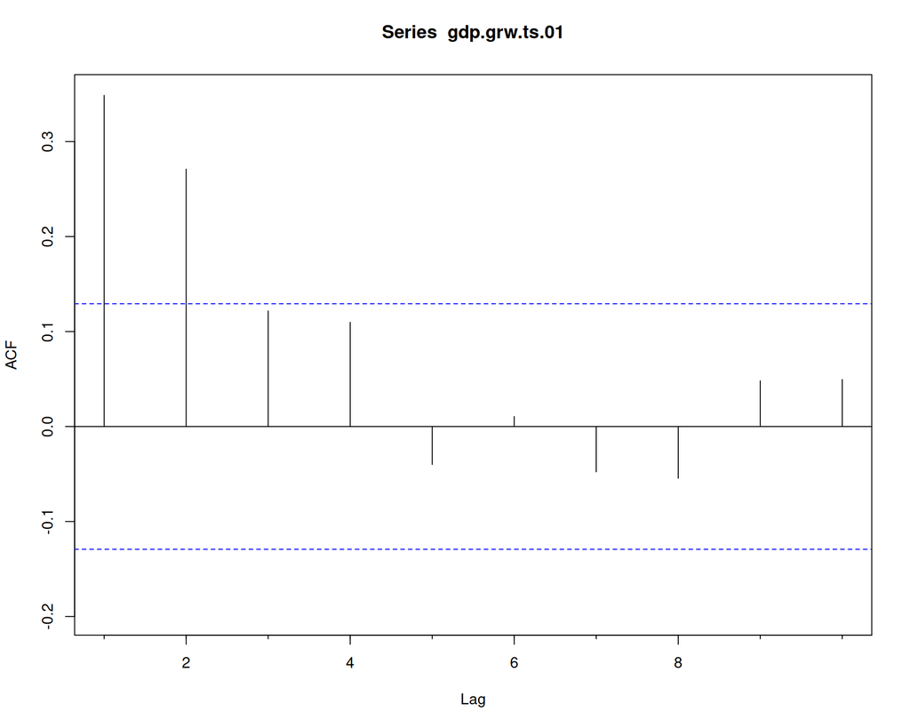

```r
par(mfrow=c(1,1))
# Use forecast package to calculate acf
gdp.grw.02.acf <- Acf(gdp.grw.ts.01, lag.max = 10, type = "correlation", plot = TRUE)
```

```r
gdp.grw.02.acf
```

```
##
## Autocorrelations of series 'gdp.grw.ts.01', by lag
##
##      0      1      2      3      4      5      6      7      8      9     10
##  1.000  0.349  0.271  0.122  0.110 -0.040  0.010 -0.048 -0.054  0.048  0.049
```

Concept, Interpretation and Discussion

Concept ACF

- Linear co-movement between current and lagged observations
  - E.g., $\widehat{\rho}_1$: Estimated correlation between $y_{t}$ and $y_{t-1}$
  - E.g., $\widehat{\rho}_j$: Estimated correlation between $y_{t}$ and $y_{t-j}$
- How useful are lagged observations to predict current observations

Interpretation

- The first four autocorrelations are positive.
- $\Rightarrow$ If GDP grows faster than average in one period, it tends to grow faster than average in the following period, too.

Discussion

- For the sample autocorrelation to be meaningful the sample mean and sample variance have to be stable over time.
- The plot of GDP in levels suggests that the mean and probably also the variance are not stable over time.
- $\Rightarrow$ The sample mean and the sample variance are not meaningful measures and thus the same is true for the sample autocorrelation.

*Add your Interpretation here!*

### Task c)

Interpret the estimation result under Model 1 in Table 5 on the exercise sheet. Is the lagged growth rate of GDP a useful predictor of the current growth rate of GDP?

Estimation

```r
# Estimation AR(1) model
ar01.dynlm <- dynlm(GDPGR ~ L(GDPGR,1),
                    data = macro.ts,
                    start = c(1962, 1), end = c(2017, 3))
```

Robust inference (for replication)

```r
# Robust inference
ct.ar01.dynlm <- coeftest(ar01.dynlm, vcov=vcovHC(ar01.dynlm, type="HC0"))
ct.ar01.dynlm
```

```r
# Robust inference
ct.ar01.dynlm <- coeftest(ar01.dynlm, vcov=vcovHC(ar01.dynlm, type="HC0"))
ct.ar01.dynlm
```

```
##
## t test of coefficients:
##
##             Estimate Std. Error t value  Pr(>|t|)
## (Intercept) 1.950062   0.322372  6.0491 6.157e-09 ***
## L(GDPGR, 1) 0.340837   0.073009  4.6684 5.264e-06 ***
## ---
## Signif. codes:  0 '***' 0.001 '**' 0.01 '*' 0.05 '.' 0.1 ' ' 1
```

Estimation results

```r
# Robust inference
ct.ar01.dynlm <- coeftest(ar01.dynlm, vcov=vcovHC(ar01.dynlm, type="HC0"))
ct.ar01.dynlm
```

```r
# Robust inference
ct.ar01.dynlm <- coeftest(ar01.dynlm, vcov=vcovHC(ar01.dynlm, type="HC0"))
ct.ar01.dynlm
```

```
##
## t test of coefficients:
##
##             Estimate Std. Error t value  Pr(>|t|)
## (Intercept) 1.950062   0.322372  6.0491 6.157e-09 ***
## L(GDPGR, 1) 0.340837   0.073009  4.6684 5.264e-06 ***
## ---
## Signif. codes:  0 '***' 0.001 '**' 0.01 '*' 0.05 '.' 0.1 ' ' 1
```

Estimation results

```
##
## ==========================
##            Model 1
## --------------------------
## constant     1.950 (0.322)
## GDPGR_L1     0.341 (0.073)
## --------------------------
## AIC          2.242
## BIC          2.273
## Num. obs.  223
## ==========================
```

Interpretation

- Estimated coefficient of the lagged growth rate is highly significant.
- $\Rightarrow$ Lagged growth rate is a useful predictor for current growth rate.

*Add your Interpretation here!*

### Task d)

Based on the estimation result under Model 1 in Table 5 on the exercise sheet forecast the growth rate of GDP in period 2017:Q4. Use the last observations depicted in Table 2 of the exercise sheet.

Last values

```
##         GDPGR TSpread
## 2016 Q3  2.74    1.26
## 2016 Q4  1.74    1.70
## 2017 Q1  1.23    1.85
## 2017 Q2  3.01    1.37
## 2017 Q3  3.11    1.20
## 2017 Q4  2.50    1.16
```

Interpretation

Prediction

$$\begin{align}
\widehat{GDPGR}_{2017:Q4|2017:Q3} &= 1.950 + 0.341 \times
GDPGR_{2017:Q3} \\
\widehat{GDPGR}_{2017:Q4|2017:Q3} &= 1.950 + 0.341 \times 3.11 \\
\widehat{GDPGR}_{2017:Q4|2017:Q3} &= 3.01
\end{align}$$

Forecast error

$$\begin{align}
GDPGR_{2017:Q4} - \widehat{GDPGR}_{2017:Q4|2017:Q3} &= 2.50 - 3.01\\
&= -0.51 \quad \text{percentage points}
\end{align}$$

*Add your Interpretation here!*

### Task e)

Interpret the estimation result depicted in Table 4 on the exercise sheet. Choose an appropriate AR(p) model for the GDP growth.

Estimation

```r
# Transform to ts variable
gdp.grw.ts <- ts(gdp.grw.ts.01, frequency = 4, start = c(1960, 2))
# Estimation using dynlm
ar00.dynlm <- dynlm(gdp.grw.ts ~ 1,
                    start = c(1962, 1), end = c(2017, 3))
ar01.dynlm <- dynlm(gdp.grw.ts ~ L(gdp.grw.ts,1),
                    start = c(1962, 1), end = c(2017, 3))
ar02.dynlm <- dynlm(gdp.grw.ts ~ L(gdp.grw.ts,1) + L(gdp.grw.ts,2),
                    start = c(1962, 1), end = c(2017, 3))
ar03.dynlm <- dynlm(gdp.grw.ts ~ L(gdp.grw.ts,1) + L(gdp.grw.ts,2) + L(gdp.grw.ts,3),
                    start = c(1962, 1), end = c(2017, 3))
ar04.dynlm <- dynlm(gdp.grw.ts ~ L(gdp.grw.ts,1) + L(gdp.grw.ts,2) + L(gdp.grw.ts,3) + L(gdp.grw.ts,4),
                    start = c(1962, 1), end = c(2017, 3))
ar05.dynlm <- dynlm(gdp.grw.ts ~ L(gdp.grw.ts,1) + L(gdp.grw.ts,2) + L(gdp.grw.ts,3) + L(gdp.grw.ts,4) + L(gdp.grw.ts,5),
                    start = c(1962, 1), end = c(2017, 3))
ar06.dynlm <- dynlm(gdp.grw.ts ~ L(gdp.grw.ts,1) + L(gdp.grw.ts,2) + L(gdp.grw.ts,3) + L(gdp.grw.ts,4) + L(gdp.grw.ts,5) + L(gdp.grw.ts,6),
                    start = c(1962, 1), end = c(2017, 3))
```

Information criteria

$R^2$

$$\begin{align}
R^2 &= 1 - \frac{SSR}{TSS}
\end{align}$$

BIC

$$\begin{align}
BIC\left(p\right)=ln\left[\frac{SSR\left(p\right)}{T}\right]+\left(p+1\right)\frac{ln\left(T\right)}{T}
\end{align}$$

AIC

$$\begin{align}
AIC\left(p\right)=ln\left[\frac{SSR\left(p\right)}{T}\right]+\left(p+1\right)\frac{2}{T}
\end{align}$$

```r
# Call function for information criteria
ar00.crit <- lag_len_crit_fun(ar00.dynlm)
ar01.crit <- lag_len_crit_fun(ar01.dynlm)
ar02.crit <- lag_len_crit_fun(ar02.dynlm)
ar03.crit <- lag_len_crit_fun(ar03.dynlm)
ar04.crit <- lag_len_crit_fun(ar04.dynlm)
ar05.crit <- lag_len_crit_fun(ar05.dynlm)
ar06.crit <- lag_len_crit_fun(ar06.dynlm)
```

Results

```r
# Collect results
res.mat <- rbind(
  cbind(ar00.crit$p,ar00.crit$ssr,ar00.crit$ssr.t,ar00.crit$log.ssr.t,ar00.crit$p1.ln.t.t,ar00.crit$BIC,ar00.crit$AIC,ar00.crit$R2),
  cbind(ar01.crit$p,ar01.crit$ssr,ar01.crit$ssr.t,ar01.crit$log.ssr.t,ar01.crit$p1.ln.t.t,ar01.crit$BIC,ar01.crit$AIC,ar01.crit$R2),
  cbind(ar02.crit$p,ar02.crit$ssr,ar02.crit$ssr.t,ar02.crit$log.ssr.t,ar02.crit$p1.ln.t.t,ar02.crit$BIC,ar02.crit$AIC,ar02.crit$R2),
  cbind(ar03.crit$p,ar03.crit$ssr,ar03.crit$ssr.t,ar03.crit$log.ssr.t,ar03.crit$p1.ln.t.t,ar03.crit$BIC,ar03.crit$AIC,ar03.crit$R2),
  cbind(ar04.crit$p,ar04.crit$ssr,ar04.crit$ssr.t,ar04.crit$log.ssr.t,ar04.crit$p1.ln.t.t,ar04.crit$BIC,ar04.crit$AIC,ar04.crit$R2),
  cbind(ar05.crit$p,ar05.crit$ssr,ar05.crit$ssr.t,ar05.crit$log.ssr.t,ar05.crit$p1.ln.t.t,ar05.crit$BIC,ar05.crit$AIC,ar05.crit$R2),
  cbind(ar06.crit$p,ar06.crit$ssr,ar06.crit$ssr.t,ar06.crit$log.ssr.t,ar06.crit$p1.ln.t.t,ar06.crit$BIC,ar06.crit$AIC,ar06.crit$R2))
colnames(res.mat) <- c("p","SSR(p)","SSR(p)/T","ln(SSR(p)/T)","(p+1)ln(T)/T","BIC(p)","AIC(p)","R2")
# Show results
res.mat
```

```
##      p   SSR(p) SSR(p)/T ln(SSR(p)/T) (p+1)ln(T)/T BIC(p) AIC(p)     R2
## [1,] 0 2336.436  10.4773       2.3492       0.0242 2.3735 2.3582 0.0000
## [2,] 1 2062.058   9.2469       2.2243       0.0485 2.2728 2.2422 0.1174
## [3,] 2 1996.840   8.9544       2.1921       0.0727 2.2649 2.2191 0.1453
## [4,] 3 1996.835   8.9544       2.1921       0.0970 2.2891 2.2280 0.1453
## [5,] 4 1989.159   8.9200       2.1883       0.1212 2.3095 2.2331 0.1486
## [6,] 5 1959.715   8.7880       2.1734       0.1455 2.3189 2.2272 0.1612
## [7,] 6 1957.732   8.7791       2.1724       0.1697 2.3421 2.2352 0.1621
```

| p | SSR(p) | SSR(p)/T | ln(SSR(p)/T) | (p+1)ln(T)/T | BIC(p) | AIC(p) | R2 |
| --- | --- | --- | --- | --- | --- | --- | --- |
| 0 | 2336.44 | 10.477 | 2.349 | 0.024 | 2.373 | 2.358 | 0.000 |
| 1 | 2062.06 | 9.247 | 2.224 | 0.048 | 2.273 | 2.242 | 0.117 |
| 2 | 1996.84 | 8.954 | 2.192 | 0.073 | 2.265 | 2.219 | 0.145 |
| 3 | 1996.84 | 8.954 | 2.192 | 0.097 | 2.289 | 2.228 | 0.145 |
| 4 | 1989.16 | 8.920 | 2.188 | 0.121 | 2.309 | 2.233 | 0.149 |
| 5 | 1959.71 | 8.788 | 2.173 | 0.146 | 2.319 | 2.227 | 0.161 |
| 6 | 1957.73 | 8.779 | 2.172 | 0.170 | 2.342 | 2.235 | 0.162 |

Interpretation

- Trade off between benefit and costs of including additional lagged variables
  - Benefit: Additional lagged variables potentially contain valuable information
  - Costs: Estimation of more coefficients introduces additional estimation error into the forecasts
- Information Criteria
  - BIC: Choose two lags
  - AIC: Choose two lags
  - $\underline{R^2}$: Always choose longest lag order ($\Rightarrow$ Not useful here!)

*Add your Interpretation here!*

### Task f)

Interpret the estimation result under Model 2 in Table 5 on the exercise sheet. Use the model to forecast the GDP growth for 2017:Q4. Discuss your results.

Estimation

```r
# Estimation AR(2) model
ar02.dynlm <- dynlm(GDPGR ~ L(GDPGR,1) + L(GDPGR,2),
                    data = macro.ts,
                    start = c(1962, 1), end = c(2017, 3))
```

Robust inference (for replication)

```r
# Robust inference
ct.ar02.dynlm <- coeftest(ar02.dynlm, vcov=vcovHC(ar02.dynlm, type="HC0"))
ct.ar02.dynlm
```

```r
# Robust inference
ct.ar02.dynlm <- coeftest(ar02.dynlm, vcov=vcovHC(ar02.dynlm, type="HC0"))
ct.ar02.dynlm
```

```
##
## t test of coefficients:
##
##             Estimate Std. Error t value   Pr(>|t|)
## (Intercept) 1.602751   0.369103  4.3423 0.00002152 ***
## L(GDPGR, 1) 0.279235   0.076380  3.6558  0.0003207 ***
## L(GDPGR, 2) 0.176734   0.076732  2.3033  0.0221980 *
## ---
## Signif. codes:  0 '***' 0.001 '**' 0.01 '*' 0.05 '.' 0.1 ' ' 1
```

Estimation results

```
##
## ===========================================
##            Model 1          Model 2
## -------------------------------------------
## constant     1.950 (0.322)    1.603 (0.369)
## GDPGR_L1     0.341 (0.073)    0.279 (0.076)
## GDPGR_L2                      0.177 (0.077)
## -------------------------------------------
## AIC          2.242            2.219
## BIC          2.273            2.265
## Num. obs.  223              223
## ===========================================
```

Interpretation I

- Estimated coefficient of the first and second lagged growth rate are significant.
- $\Rightarrow$ First and second lagged growth rate is a useful predictor of current growth rate.

*Add your Interpretation here!*

Forecast

Prediction

$$\begin{align}
\widehat{GDPGR}_{2017:Q4|2017:Q3,2017:Q2} &= 1.603 + 0.279 \times
GDPGR_{2017:Q3} + 0.177 \times GDPGR_{2017:Q2} \\
\widehat{GDPGR}_{2017:Q4|2017:Q3,2017:Q2} &= 1.603 + 0.279 \times
3.11 + 0.177 \times 3.01 \\
\widehat{GDPGR}_{2017:Q4|2017:Q3,2017:Q2} &= 3.00
\end{align}$$

Forecast error

$$\begin{align}
GDPGR_{2017:Q4} - \widehat{GDPGR}_{2017:Q4|2017:Q3} &= 2.50 - 3.00\\
&= -0.50 \quad \text{percentage points}
\end{align}$$

*Add your Interpretation here!*

Interpretation II

Comparison of forecasting error

- AR(1)-model: $-0.51$ percentage points
- AR(2)-model: $-0.50$ percentage points
- $\Rightarrow$ AR(2)-model has a lower (absolute) forecasting error.

*Add your Interpretation here!*

### Task g)

Compare the time series plots of the GDP growth rate and the term spread in Figure 1 on the exercise sheet. Discuss whether the term spread is a potential predictor for future GDP growth.

Plot

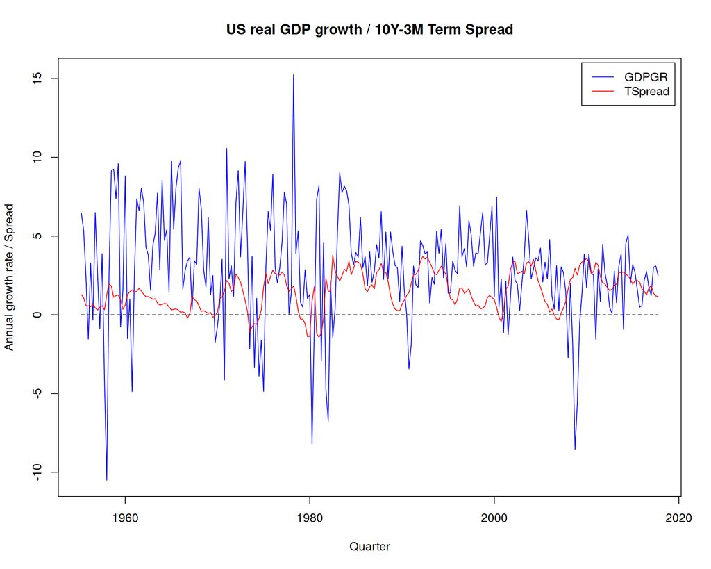

```r
# Time series plot of GDPGR and term spread
plot(x = tax, y = macro.dat$GDPGR, type = "l", col = "blue",
     main = "US real GDP growth / 10Y-3M Term Spread",
     xlab = "Quarter",
     ylab = "Annual growth rate / Spread")
lines(x = tax, y = macro.dat$TSpread, type = "l", col = "red")
lines(x = tax, y = rep(0,length(tax)), type = "l", lty = 2)
legend("topright",
       legend = c("GDPGR", "TSpread"),
       col = c("blue", "red"),
       lty = 1, inset = 0.01)
```

Interpretation

*Add your Interpretation here!*

### Task h)

Interpret the estimation result under Model 3 in Table 5 on the exercise sheet. Use the model to forecast the GDP growth for 2017:Q4. Discuss your results.

Estimation

```r
# Estimation ADL model
adl.dynlm <- dynlm(GDPGR ~ L(GDPGR,1) + L(GDPGR,2) + L(TSpread,1) + L(TSpread,2),
                   data = macro.ts,
                   start = c(1962, 1), end = c(2017, 3))
```

Robust inference (for replication)

```r
# Robust inference
ct.adl.dynlm <- coeftest(adl.dynlm, vcov=vcovHC(adl.dynlm, type="HC1"))
ct.adl.dynlm
```

```r
# Robust inference
ct.adl.dynlm <- coeftest(adl.dynlm, vcov=vcovHC(adl.dynlm, type="HC1"))
ct.adl.dynlm
```

```
##
## t test of coefficients:
##
##                Estimate Std. Error t value Pr(>|t|)
## (Intercept)    0.944662   0.461770  2.0457 0.041983 *
## L(GDPGR, 1)    0.245699   0.075965  3.2344 0.001408 **
## L(GDPGR, 2)    0.175626   0.075919  2.3133 0.021636 *
## L(TSpread, 1) -0.133785   0.419616 -0.3188 0.750162
## L(TSpread, 2)  0.622534   0.427773  1.4553 0.147028
## ---
## Signif. codes:  0 '***' 0.001 '**' 0.01 '*' 0.05 '.' 0.1 ' ' 1
```

Estimation results

```
##
## ================================================================
##                Model 1          Model 2          Model 3
## ----------------------------------------------------------------
## (Intercept)      1.950 (0.322)    1.603 (0.369)    0.945 (0.462)
## L(GDPGR, 1)      0.341 (0.073)    0.279 (0.076)    0.246 (0.076)
## L(GDPGR, 2)                       0.177 (0.077)    0.176 (0.076)
## L(TSpread, 1)                                     -0.134 (0.420)
## L(TSpread, 2)                                      0.623 (0.428)
## ----------------------------------------------------------------
## AIC              2.242            2.219            2.196
## BIC              2.273            2.265            2.272
## Num. obs.      223              223              223
## ================================================================
```

Interpretation

- Estimated coefficient of the lagged term spread are not quite significant.
- Using term spread could still reduce the out-of-sample forecasting error.

*Add your Interpretation here!*

Forecast

Prediction

$$\begin{align}
\widehat{GDPGR}_{2017:Q4|2017:Q3,2017:Q2} &= 0.945 + 0.246 \times
GDPGR_{2017:Q3} + 0.176 \times GDPGR_{2017:Q2} \\
&= -0.134 \times TSpread_{2017:Q3} + 0.623 \times TSpread_{2017:Q2}
\\
\widehat{GDPGR}_{2017:Q4|2017:Q3,2017:Q2} &= 0.945 + 0.246 \times
3.11 + 0.176 \times 3.01 \\
&\phantom{=} - 0.13 \times 1.200 + 0.623 \times 1.37 \\
\widehat{GDPGR}_{2017:Q4|2017:Q3,2017:Q2} &= 2.94
\end{align}$$

Forecast error

$$\begin{align}
GDPGR_{2017:Q4} - \widehat{GDPGR}_{2017:Q4|2017:Q3} &= 2.50 - 2.94\\
&= -0.44 \quad \text{percentage points}
\end{align}$$

*Add your Interpretation here!*

Interpretation II

Comparison of forecasting error

- AR(1)-model: $-0.51$ percentage points
- AR(2)-model: $-0.50$ percentage points
- ADL-model: $-0.44$ percentage points
- $\Rightarrow$ ADL-model has a lower (absolute) forecasting error.
- $\Rightarrow$ Use so-called pseudo out of sample (POOS) forecast error to compare the three models more more thoroughly.

*Add your Interpretation here!*

Back To *Start*